# Project 2

Bruce Phan

10/24/2020

## Introduction

Storms and other severe weather events can cause both public health and economic problems for communities and municipalities. Many severe events can result in fatalities, injuries, and property damage, and preventing such outcomes to the extent possible is a key concern.

This project involves exploring the U.S. National Oceanic and Atmospheric Administration’s (NOAA) storm database. This database tracks characteristics of major storms and weather events in the United States, including when and where they occur, as well as estimates of any fatalities, injuries, and property damage.

## Loading Libraries and Data

Data is extracted from this source , unzip and load into R using csv https://d396qusza40orc.cloudfront.net/repdata%2Fdata%2FStormData.csv.bz2

```r
library(dplyr)
```

```r
library(data.table)
library(ggplot2)
library(knitr)
setwd("C:/Users/bruce/Desktop/Data/Coursera/reproducible research/hw2")

data<-fread("repdata_data_StormData.csv")
```

## Data Processing

Data is organized by EVTYPE which inidcates the type of event. FATALITIES and INJURIES indicate the damage to population by the event type. PROPDMG and CROPDMG are property damage and crop damage respectively. We will focus on plotting the effect for fatalities and damage.

A column DAMAGE is added to the data to sumup the damge for crop and property damage.

```r
length(unique(data$EVTYPE))
```

[1] 985

```r
data$DAMAGE<-data$PROPDMG+data$CROPDMG
```

There are total 985 event types in the data , with many has similar meaning like “TORNADO” and “TORNADA F0” … we should try to clean the data up and group them together.

```r
data$EVTYPE <- ifelse(substr(data$EVTYPE,1,4)=="TORN","TORNADO",data$EVTYPE)

data$EVTYPE <- ifelse(substr(data$EVTYPE,1,6)=="TSTM W","TSTM WIND",data$EVTYPE)


data$EVTYPE <- ifelse(substr(data$EVTYPE,1,6)=="WINTER","WINTER WEATHER",data$EVTYPE)

data$EVTYPE <- ifelse(substr(data$EVTYPE,1,4)=="WIND","WIND",data$EVTYPE)

data$EVTYPE <- ifelse(substr(data$EVTYPE,1,5)=="FLOOD","FLOOD",data$EVTYPE)

data$EVTYPE <- ifelse(substr(data$EVTYPE,1,11)=="FLASH FLOOD","FLASH FLOOD",data$EVTYPE)

data$EVTYPE <- ifelse(substr(data$EVTYPE,1,7)=="BLIZZAR","BLIZZARD",data$EVTYPE)

data$EVTYPE <- ifelse(substr(data$EVTYPE,1,7)=="blizzar","BLIZZARD",data$EVTYPE)

data$EVTYPE <- ifelse(substr(data$EVTYPE,1,13)=="FREEZING RAIN","FREEZING RAIN",data$EVTYPE)

data$EVTYPE <- ifelse(substr(data$EVTYPE,1,4)=="COLD","COLD",data$EVTYPE)

data$EVTYPE <- ifelse(substr(data$EVTYPE,1,12)=="BLOWING SNOW","SNOW",data$EVTYPE)

data$EVTYPE <- ifelse(substr(data$EVTYPE,1,14)=="EXCESSIVE HEAT","HEAT",data$EVTYPE)
```

In order to analyze the data and answere the question about economics and casualties, we will group the data by event type and summarize the fatalities and injuries as well as damage ( to sum of property and crop damage). Data will be ranked to keep the top 12 event for each category.

```r
fatal<-data %>% group_by(EVTYPE) %>% summarise(FATALITIES = sum(FATALITIES)) %>%
  filter(FATALITIES > 10) %>% top_n(12) %>% arrange(desc(FATALITIES))
injury<-data %>% group_by(EVTYPE) %>% summarise(INJURIES = sum(INJURIES)) %>%
  filter(INJURIES > 10) %>% top_n(12) %>% arrange(desc(INJURIES))
propdmg<-data %>% group_by(EVTYPE) %>% summarise(DAMAGE = sum(DAMAGE)) %>%
  filter(DAMAGE > 10) %>% top_n(12) %>% arrange(desc(DAMAGE))
```

## Results

FATALITIES , INJURIES , DAMAGE are plotted for event type

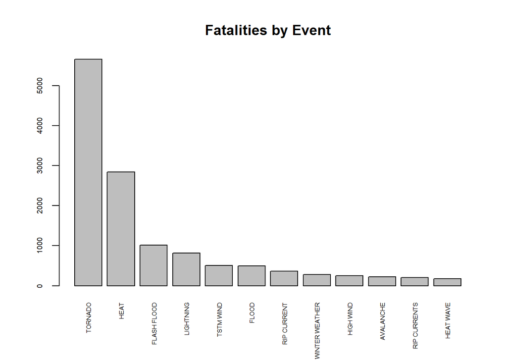

```r
barplot(fatal$FATALITIES,names.arg = fatal$EVTYPE,las=3,
        cex.axis=0.6,cex.names=0.5,
        main="Fatalities by Event"
        )
```

The “Fatalties by Event” shows that TORNADO is the most deadly event follows by heat.

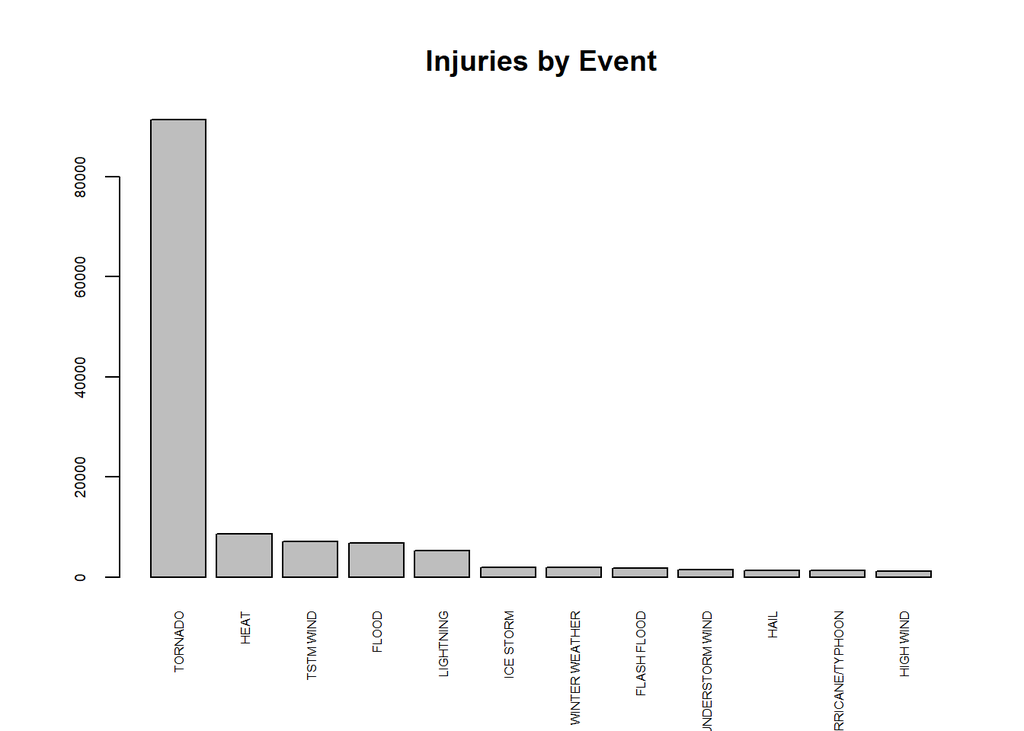

```r
barplot(injury$INJURIES,names.arg = injury$EVTYPE,las=3,
        cex.axis=0.6,cex.names=0.5,
        main="Injuries by Event"
)
```

The “Injuries by Event” shows that TORNADO is the most event causing injuries.

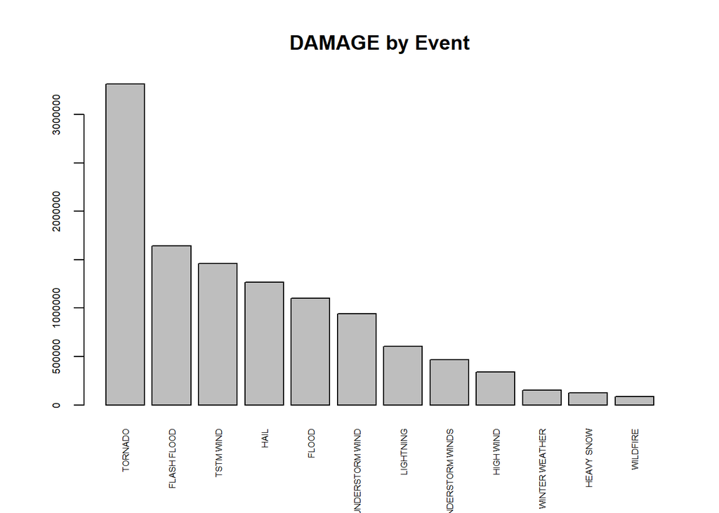

```r
barplot(propdmg$DAMAGE,names.arg = propdmg$EVTYPE,las=3,
        cex.axis=0.6,cex.names=0.5,
        main="DAMAGE by Event"
)
```

As we all can see Tornado is the most harmful event in both casualties and property damage.